# Bellabeat Case Study

Angela Jones

9/20/2021

# Case Study for Google Certificate

## Bellabeat: How Can a Wellness Technology Company Play It Smart?

Hello, I am junior data analyst and this is a project in the certificate program at Google. This document will outline the business task and code to help the company make business driven decisions utilizing the phases of data analysis.

**Business Task** Construct a targeted marketing strategy based upon how consumers are currently using their wearable smart devices.

*What is the problem you are trying to solve? Bellabeat’s stakeholders want to know:  
How are consumers using their wearable smart devices?

*How can your insights drive business decisions? This analysis will help the company build a target marketing strategy.

*Company Background*

About the company Urška Sršen and Sando Mur founded Bellabeat, a high-tech company that manufactures health-focused smart products. Sršen used her background as an artist to develop beautifully designed technology that informs and inspires women around the world. Collecting data on activity, sleep, stress, and reproductive health has allowed Bellabeat to empower women with knowledge about their own health and habits. Since it was founded in 2013, Bellabeat has grown rapidly and quickly positioned itself as a tech-driven wellness company for women. By 2016, Bellabeat had opened offices around the world and launched multiple products. Bellabeat products became available through a growing number of online retailers in addition to their own e-commerce channel on their website.

**Dataset** The dataset used for this mock scenario is cited as follows:

Furberg, R., Brinton, J., Keating, M., & Ortiz, A. (2016). Crowd-sourced Fitbit datasets 03.12.2016-05.12.2016 [Data set]. Zenodo. https://doi.org/10.5281/zenodo.53894

It was uploaded from a Kaggle account into R Studio Cloud

FitBit Fitness Tracker Data (CC0: Public Domain, dataset made available through Mobius):

There 18 csv files in the dataset in long format

The study lists the following fitbit usage in the following areas:

*Physical activity (daily steps and intensity)* Heart rate *Sleep monitoring* Weight tracking

Using the ROCCC method this data is problematic in the following areas:

*Reliable: it may be reliable as it is cited work but is is from a third party Amazon Mechanical Turk which is a crowdsourcing marketplace and not a notable industry source

*Original: it is from an original study

*Comprehensive: it does complement Bellabeat smart device features but is a small scale sample.

*Current: it is not current as it is over 5 years old

*Cited: it is cited

I find this data is flawed but for the purposes of this mock scenario, I will continue to use this data for analysis.

**Sort and Filter** # Special note used # because error in knitting to avoid execute commands

```r
#install.packages('tidyverse')
library(tidyverse)
```

#remove here and janitor to knit

#library(here) library(janitor)

[output not shown]

```r
library(dplyr)
```

```r
daily_activity <- read.csv("dailyActivity_merged.csv")
daily_steps<-read.csv("dailySteps_merged.csv")
daily_calories <- read.csv("dailyCalories_merged.csv")
daily_intensity <-read.csv("dailyIntensities_merged.csv")
heart_rate <-read.csv("heartrate_seconds_merged.csv")
weight_log <-read.csv("weightLogInfo_merged_cl.csv")
hourly_calories <-read.csv("hourlyCalories_merged.csv")
```

```r
sleep_day <- read.csv("sleepDay_merged.csv")
```

```r
n_distinct(daily_activity$Id)
```

```
## [1] 33
```

```r
n_distinct(sleep_day$Id)
```

```
## [1] 24
```

```r
n_distinct(daily_calories$Id)
```

```
## [1] 33
```

```r
n_distinct(daily_steps$Id)
```

```
## [1] 33
```

```r
n_distinct(heart_rate$Id)
```

```
## [1] 14
```

```r
n_distinct(weight_log$Id)
```

```
## [1] 8
```

```r
n_distinct(daily_intensity$Id)
```

```
## [1] 33
```

*Observations Part 1* My first observation is either there was not enough participant interest or the study was limited in heart rate and weight tracking files. Using the n_distinct function the unique users were much lower. And the data in heart rate and weight tracking was not enough to plot relationships.

Since the business task is to determine how participants were using their smart device wearable. I eliminated analysis on the files containing heart rate and weight tracking.

So the data analysis will be based on: *Physical activity (daily steps and intensity)

*Sleep monitoring

Further, using glimpse and head I was able to get a compact view of the data. I was not exactly sure at this point how I would proceed in analyzing the data but I did notice in the sleepDay file the date had a time stamp of 12:00 am. So I cleaned that column to remove the time stamp.

I obtained a summary of the main files that I would use to analyze the data to get median and average results.

As I am new to this field, I searched and found code examples on both the RStudio help feature and stackflow.com including aesthetics and visualizations. I have included all of my attempts to plot the data. I wanted to show the contrast in this rmd to make actual presentation in Google slides.

```r
glimpse(heart_rate)
```

```
## Rows: 2,483,658
## Columns: 3
## $ Id    <dbl> 2022484408, 2022484408, 2022484408, 2022484408, 2022484408, 2022~
## $ Time  <chr> "4/12/2016 7:21:00 AM", "4/12/2016 7:21:05 AM", "4/12/2016 7:21:~
## $ Value <int> 97, 102, 105, 103, 101, 95, 91, 93, 94, 93, 92, 89, 83, 61, 60, ~
```

```r
head(daily_activity)
```

```
##           Id ActivityDate TotalSteps TotalDistance TrackerDistance
## 1 1503960366    4/12/2016      13162          8.50            8.50
## 2 1503960366    4/13/2016      10735          6.97            6.97
## 3 1503960366    4/14/2016      10460          6.74            6.74
## 4 1503960366    4/15/2016       9762          6.28            6.28
## 5 1503960366    4/16/2016      12669          8.16            8.16
## 6 1503960366    4/17/2016       9705          6.48            6.48
##   LoggedActivitiesDistance VeryActiveDistance ModeratelyActiveDistance
## 1                        0               1.88                     0.55
## 2                        0               1.57                     0.69
## 3                        0               2.44                     0.40
## 4                        0               2.14                     1.26
## 5                        0               2.71                     0.41
## 6                        0               3.19                     0.78
##   LightActiveDistance SedentaryActiveDistance VeryActiveMinutes
## 1                6.06                       0                25
## 2                4.71                       0                21
## 3                3.91                       0                30
## 4                2.83                       0                29
## 5                5.04                       0                36
## 6                2.51                       0                38
##   FairlyActiveMinutes LightlyActiveMinutes SedentaryMinutes Calories
## 1                  13                  328              728     1985
## 2                  19                  217              776     1797
## 3                  11                  181             1218     1776
## 4                  34                  209              726     1745
## 5                  10                  221              773     1863
## 6                  20                  164              539     1728
```

```r
head(daily_intensity)
```

```
##           Id ActivityDay SedentaryMinutes LightlyActiveMinutes
## 1 1503960366   4/12/2016              728                  328
## 2 1503960366   4/13/2016              776                  217
## 3 1503960366   4/14/2016             1218                  181
## 4 1503960366   4/15/2016              726                  209
## 5 1503960366   4/16/2016              773                  221
## 6 1503960366   4/17/2016              539                  164
##   FairlyActiveMinutes VeryActiveMinutes SedentaryActiveDistance
## 1                  13                25                       0
## 2                  19                21                       0
## 3                  11                30                       0
## 4                  34                29                       0
## 5                  10                36                       0
## 6                  20                38                       0
##   LightActiveDistance ModeratelyActiveDistance VeryActiveDistance
## 1                6.06                     0.55               1.88
## 2                4.71                     0.69               1.57
## 3                3.91                     0.40               2.44
## 4                2.83                     1.26               2.14
## 5                5.04                     0.41               2.71
## 6                2.51                     0.78               3.19
```

```r
glimpse(daily_activity)
```

```
## Rows: 940
## Columns: 15
## $ Id                       <dbl> 1503960366, 1503960366, 1503960366, 150396036~
## $ ActivityDate             <chr> "4/12/2016", "4/13/2016", "4/14/2016", "4/15/~
## $ TotalSteps               <int> 13162, 10735, 10460, 9762, 12669, 9705, 13019~
## $ TotalDistance            <dbl> 8.50, 6.97, 6.74, 6.28, 8.16, 6.48, 8.59, 9.8~
## $ TrackerDistance          <dbl> 8.50, 6.97, 6.74, 6.28, 8.16, 6.48, 8.59, 9.8~
## $ LoggedActivitiesDistance <dbl> 0, 0, 0, 0, 0, 0, 0, 0, 0, 0, 0, 0, 0, 0, 0, ~
## $ VeryActiveDistance       <dbl> 1.88, 1.57, 2.44, 2.14, 2.71, 3.19, 3.25, 3.5~
## $ ModeratelyActiveDistance <dbl> 0.55, 0.69, 0.40, 1.26, 0.41, 0.78, 0.64, 1.3~
## $ LightActiveDistance      <dbl> 6.06, 4.71, 3.91, 2.83, 5.04, 2.51, 4.71, 5.0~
## $ SedentaryActiveDistance  <dbl> 0, 0, 0, 0, 0, 0, 0, 0, 0, 0, 0, 0, 0, 0, 0, ~
## $ VeryActiveMinutes        <int> 25, 21, 30, 29, 36, 38, 42, 50, 28, 19, 66, 4~
## $ FairlyActiveMinutes      <int> 13, 19, 11, 34, 10, 20, 16, 31, 12, 8, 27, 21~
## $ LightlyActiveMinutes     <int> 328, 217, 181, 209, 221, 164, 233, 264, 205, ~
## $ SedentaryMinutes         <int> 728, 776, 1218, 726, 773, 539, 1149, 775, 818~
## $ Calories                 <int> 1985, 1797, 1776, 1745, 1863, 1728, 1921, 203~
```

```r
glimpse(sleep_day)
```

```
## Rows: 413
## Columns: 5
## $ Id                 <dbl> 1503960366, 1503960366, 1503960366, 1503960366, 150~
## $ SleepDay           <chr> "4/12/2016 12:00:00 AM", "4/13/2016 12:00:00 AM", "~
## $ TotalSleepRecords  <int> 1, 2, 1, 2, 1, 1, 1, 1, 1, 1, 1, 1, 1, 1, 1, 1, 1, ~
## $ TotalMinutesAsleep <int> 327, 384, 412, 340, 700, 304, 360, 325, 361, 430, 2~
## $ TotalTimeInBed     <int> 346, 407, 442, 367, 712, 320, 377, 364, 384, 449, 3~
```

```r
daily_activity %>%
  select(TotalSteps,
         VeryActiveDistance,
         LightActiveDistance,
         Calories) %>%
  summary()
```

```
##    TotalSteps    VeryActiveDistance LightActiveDistance    Calories
##  Min.   :    0   Min.   : 0.000     Min.   : 0.000      Min.   :   0
##  1st Qu.: 3790   1st Qu.: 0.000     1st Qu.: 1.945      1st Qu.:1828
##  Median : 7406   Median : 0.210     Median : 3.365      Median :2134
##  Mean   : 7638   Mean   : 1.503     Mean   : 3.341      Mean   :2304
##  3rd Qu.:10727   3rd Qu.: 2.053     3rd Qu.: 4.782      3rd Qu.:2793
##  Max.   :36019   Max.   :21.920     Max.   :10.710      Max.   :4900
```

```r
sleep_day$SleepDay <- as.Date(sleep_day$SleepDay , format = "%m/%d/%y")
```

```r
glimpse(sleep_day)
```

```
## Rows: 413
## Columns: 5
## $ Id                 <dbl> 1503960366, 1503960366, 1503960366, 1503960366, 150~
## $ SleepDay           <date> 2020-04-12, 2020-04-13, 2020-04-15, 2020-04-16, 20~
## $ TotalSleepRecords  <int> 1, 2, 1, 2, 1, 1, 1, 1, 1, 1, 1, 1, 1, 1, 1, 1, 1, ~
## $ TotalMinutesAsleep <int> 327, 384, 412, 340, 700, 304, 360, 325, 361, 430, 2~
## $ TotalTimeInBed     <int> 346, 407, 442, 367, 712, 320, 377, 364, 384, 449, 3~
```

```r
sleep_day %>%
  select(TotalMinutesAsleep,
         TotalTimeInBed,
         TotalSleepRecords) %>%
  summary()
```

```
##  TotalMinutesAsleep TotalTimeInBed  TotalSleepRecords
##  Min.   : 58.0      Min.   : 61.0   Min.   :1.000
##  1st Qu.:361.0      1st Qu.:403.0   1st Qu.:1.000
##  Median :433.0      Median :463.0   Median :1.000
##  Mean   :419.5      Mean   :458.6   Mean   :1.119
##  3rd Qu.:490.0      3rd Qu.:526.0   3rd Qu.:1.000
##  Max.   :796.0      Max.   :961.0   Max.   :3.000
```

```r
daily_intensity %>%
  select(SedentaryMinutes,
         LightlyActiveMinutes,
         VeryActiveMinutes) %>%
  summary()
```

```
##  SedentaryMinutes LightlyActiveMinutes VeryActiveMinutes
##  Min.   :   0.0   Min.   :  0.0        Min.   :  0.00
##  1st Qu.: 729.8   1st Qu.:127.0        1st Qu.:  0.00
##  Median :1057.5   Median :199.0        Median :  4.00
##  Mean   : 991.2   Mean   :192.8        Mean   : 21.16
##  3rd Qu.:1229.5   3rd Qu.:264.0        3rd Qu.: 32.00
##  Max.   :1440.0   Max.   :518.0        Max.   :210.00
```

*Observations Part 2* Based on the review so far I know my concentration will be on daily activity, daily intensity and sleep. The median average for total steps was 7406. And most users were most likely to be less active and more sedentary. The sleep records themselves provided only limited data regarding sleep behavior for minutes asleep and minutes in bed. This may be in correlation to their activity. (calorie-distance)(sleep -activity)

I also search RStudio for information on how to plot minutes versus total steps. And I found a page that discussed how to change axis scales at statology.org

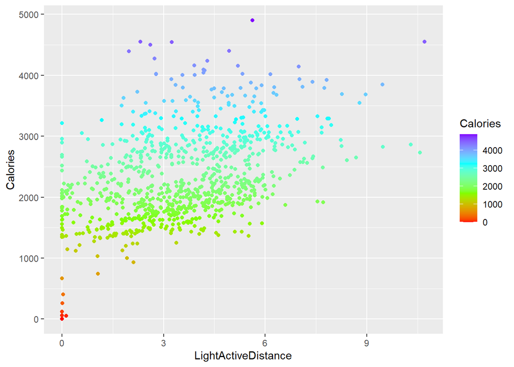

```r
ggplot(daily_activity, aes(x=LightActiveDistance, y=Calories, color=Calories)) +
  geom_point() +
  scale_color_gradientn(colours = rainbow(4),
                        na.value = "transparent")
```

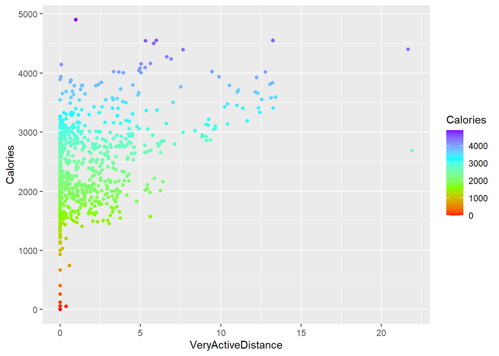

```r
ggplot(daily_activity, aes(x=VeryActiveDistance, y=Calories, color=Calories)) +
  geom_point() +
  scale_color_gradientn(colours = rainbow(4),
                        na.value = "transparent")
```

**Merged Data** I created a merged data frame to combine the daily activity and sleep day files. The purpose was to plot correlations between steps, sleep, total minutes asleep and total minutes in bed.

I did not like the rendering of my initial plots but it got me closer to the trend I was noticing.

```r
merged.data.frame<-merge(daily_activity, sleep_day, by="Id")
```

```r
glimpse(merged.data.frame)
```

```
## Rows: 12,441
## Columns: 19
## $ Id                       <dbl> 1503960366, 1503960366, 1503960366, 150396036~
## $ ActivityDate             <chr> "5/7/2016", "5/7/2016", "5/7/2016", "5/7/2016~
## $ TotalSteps               <int> 11992, 11992, 11992, 11992, 11992, 11992, 119~
## $ TotalDistance            <dbl> 7.71, 7.71, 7.71, 7.71, 7.71, 7.71, 7.71, 7.7~
## $ TrackerDistance          <dbl> 7.71, 7.71, 7.71, 7.71, 7.71, 7.71, 7.71, 7.7~
## $ LoggedActivitiesDistance <dbl> 0, 0, 0, 0, 0, 0, 0, 0, 0, 0, 0, 0, 0, 0, 0, ~
## $ VeryActiveDistance       <dbl> 2.46, 2.46, 2.46, 2.46, 2.46, 2.46, 2.46, 2.4~
## $ ModeratelyActiveDistance <dbl> 2.12, 2.12, 2.12, 2.12, 2.12, 2.12, 2.12, 2.1~
## $ LightActiveDistance      <dbl> 3.13, 3.13, 3.13, 3.13, 3.13, 3.13, 3.13, 3.1~
## $ SedentaryActiveDistance  <dbl> 0, 0, 0, 0, 0, 0, 0, 0, 0, 0, 0, 0, 0, 0, 0, ~
## $ VeryActiveMinutes        <int> 37, 37, 37, 37, 37, 37, 37, 37, 37, 37, 37, 3~
## $ FairlyActiveMinutes      <int> 46, 46, 46, 46, 46, 46, 46, 46, 46, 46, 46, 4~
## $ LightlyActiveMinutes     <int> 175, 175, 175, 175, 175, 175, 175, 175, 175, ~
## $ SedentaryMinutes         <int> 833, 833, 833, 833, 833, 833, 833, 833, 833, ~
## $ Calories                 <int> 1821, 1821, 1821, 1821, 1821, 1821, 1821, 182~
## $ SleepDay                 <date> 2020-04-12, 2020-04-13, 2020-04-15, 2020-04-~
## $ TotalSleepRecords        <int> 1, 2, 1, 2, 1, 1, 1, 1, 1, 1, 1, 1, 1, 1, 1, ~
## $ TotalMinutesAsleep       <int> 327, 384, 412, 340, 700, 304, 360, 325, 361, ~
## $ TotalTimeInBed           <int> 346, 407, 442, 367, 712, 320, 377, 364, 384, ~
```

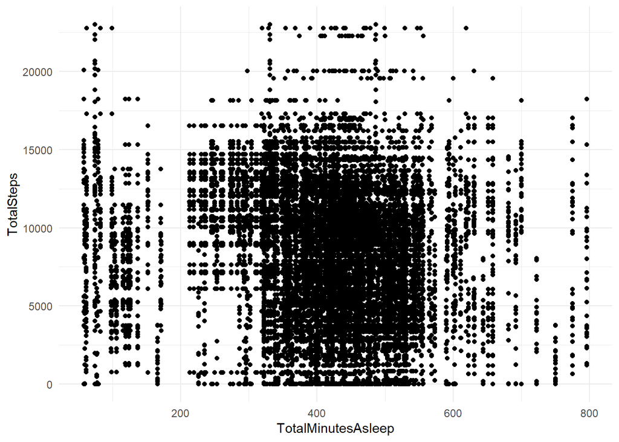

```r
ggplot(merged.data.frame, aes(x = TotalMinutesAsleep, y = TotalSteps)) + geom_jitter(position = position_jitter(0.10)) + theme_minimal()
```

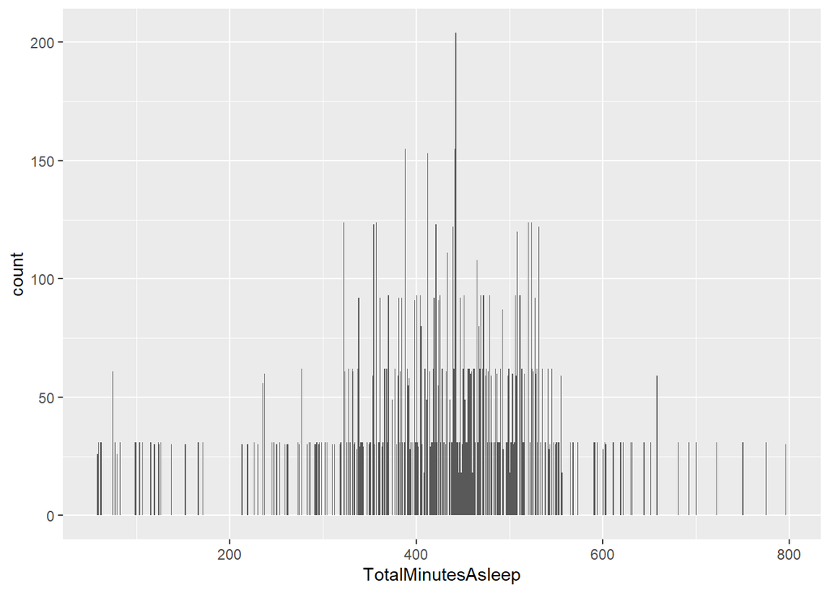

```r
ggplot(data=merged.data.frame, aes(x=TotalMinutesAsleep)) +
  geom_bar()
```

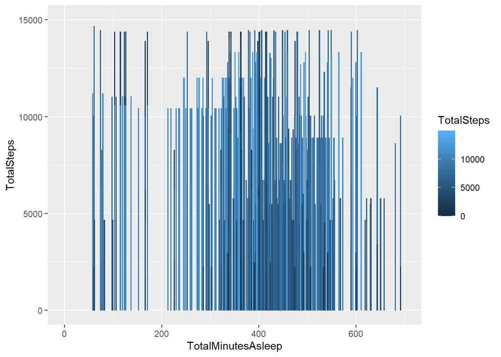

```r
ggplot(data = merged.data.frame) +
  geom_col(mapping=aes(x =TotalMinutesAsleep, y=TotalSteps, color=TotalSteps))+
  xlim(0, 700) +
  ylim(0, 15000)
```

```r
merged.data.frame<-merge(daily_activity, sleep_day, by="Id")
```

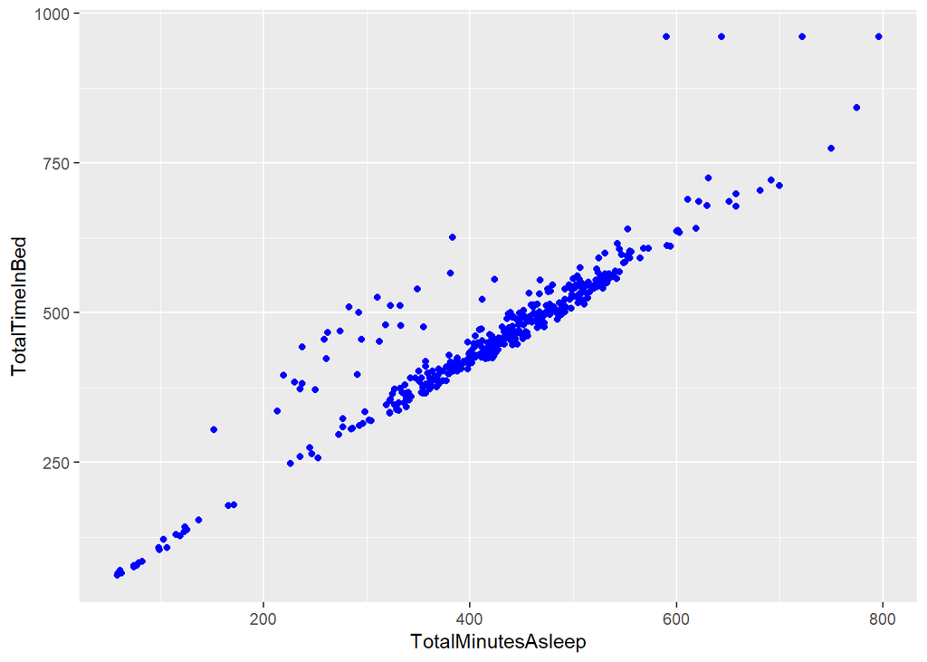

```r
ggplot(data = merged.data.frame) +
  geom_point(mapping = aes(x = TotalMinutesAsleep, y = TotalTimeInBed, color = Id), color="blue")
```

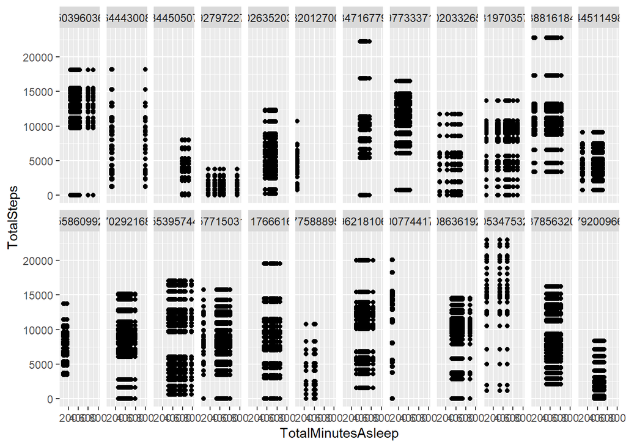

```r
ggplot(data = merged.data.frame) +
  geom_point(mapping = aes(x = TotalMinutesAsleep, y =TotalSteps)) +
  facet_wrap(~ Id, nrow = 2)
```

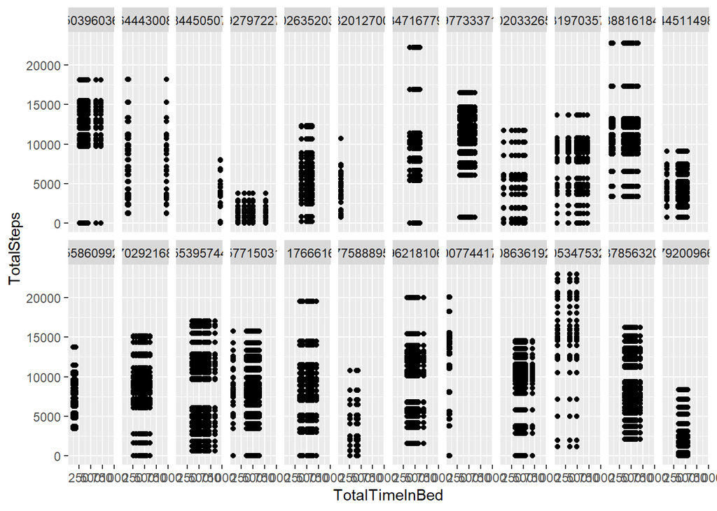

```r
ggplot(data = merged.data.frame) +
  geom_point(mapping = aes(x = TotalTimeInBed, y =TotalSteps)) +
  facet_wrap(~ Id, nrow = 2)
```

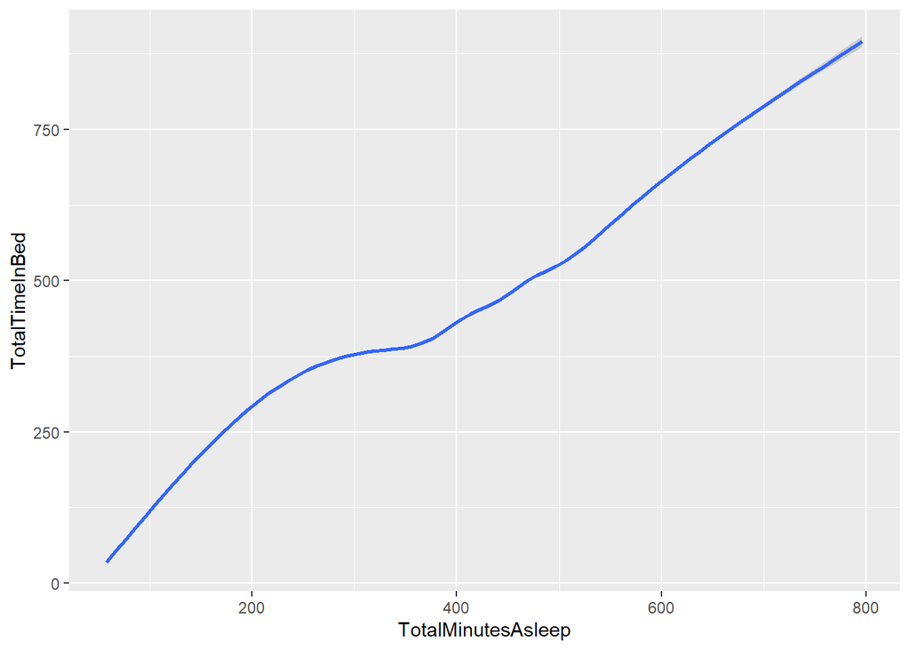

```r
ggplot(data = merged.data.frame) +
  geom_smooth(mapping = aes(x = TotalMinutesAsleep, y = TotalTimeInBed, color=Id ))
```

```r
show.legend = FALSE
```

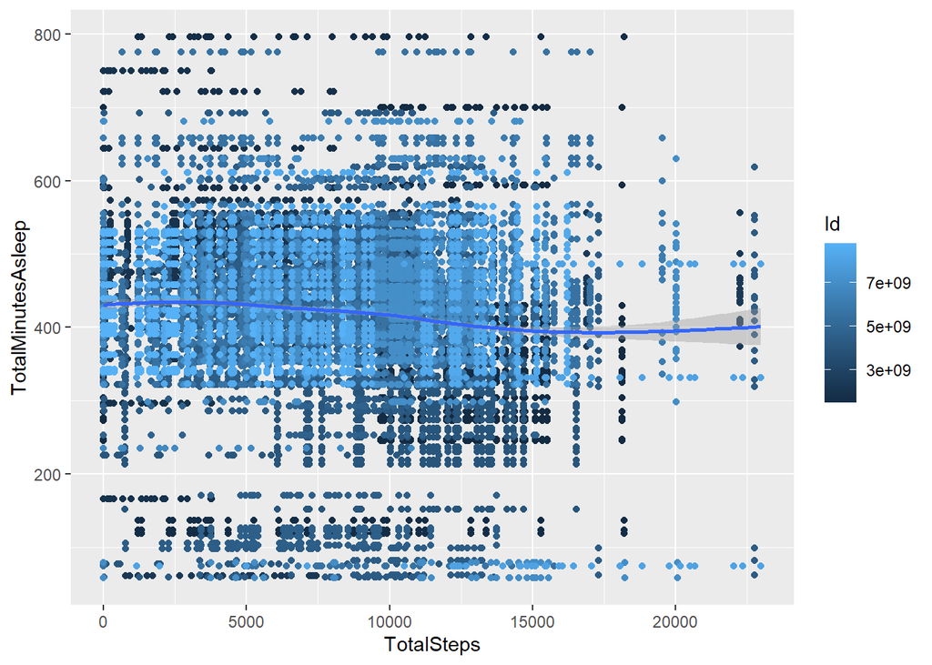

```r
ggplot(data = merged.data.frame, mapping = aes(x = TotalSteps, y = TotalMinutesAsleep)) +
  geom_point(mapping = aes(color = Id)) +
  geom_smooth()
```

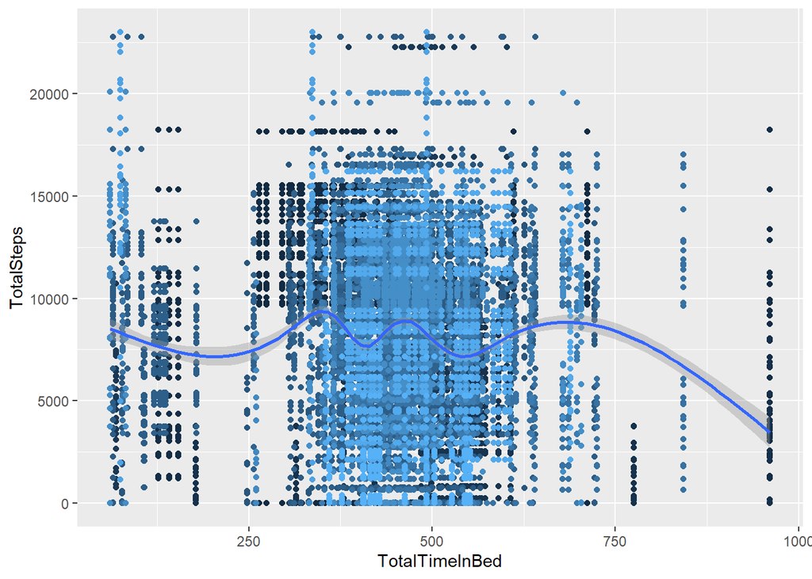

```r
ggplot(data = merged.data.frame, mapping = aes(x =TotalTimeInBed, y =TotalSteps)) +
  geom_point(mapping = aes(color = Id, stat = "summary", fun = "mean") ) +
  geom_smooth()+
  theme(legend.position = "none")
```

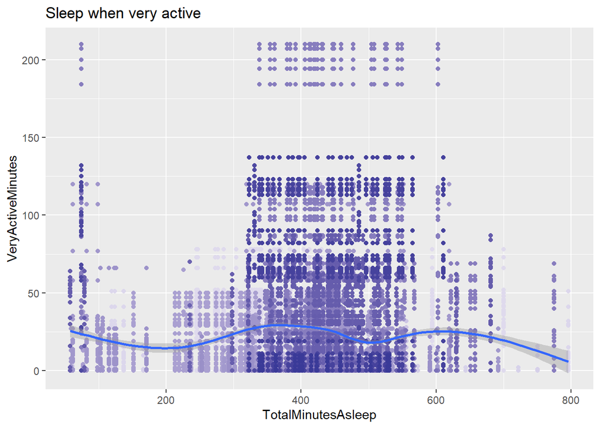

```r
ggplot(data = merged.data.frame, mapping = aes(x = TotalMinutesAsleep, y =VeryActiveMinutes)) +
  geom_point(mapping = aes(color = Id, stat = "summary", fun = "mean") ) +
  scale_colour_gradient2()+
  theme(legend.position = "none")+
  geom_smooth()+
  labs(title="Sleep when very active")
```

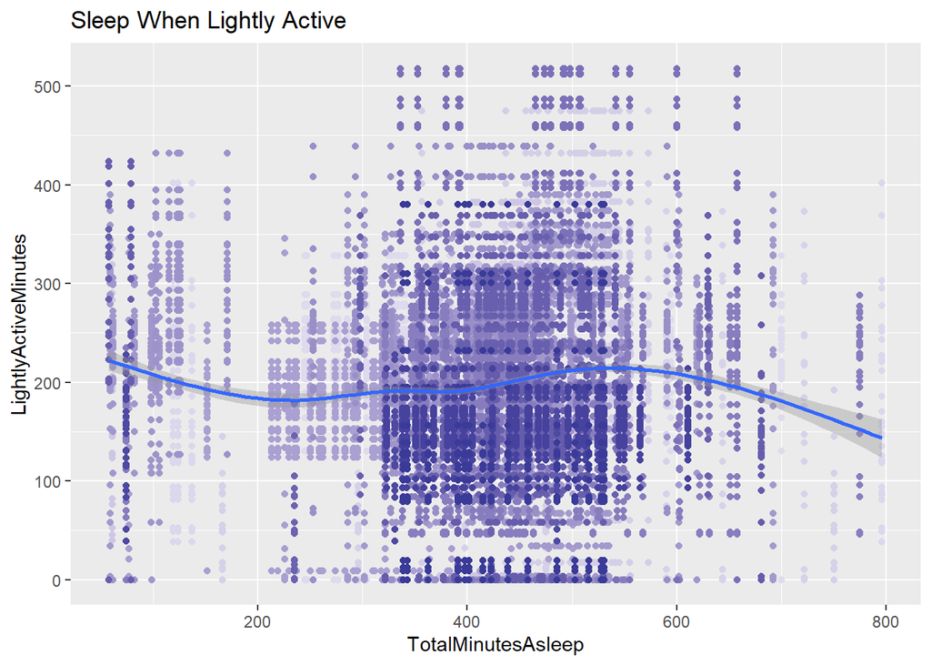

```r
ggplot(data = merged.data.frame, mapping = aes(x = TotalMinutesAsleep, y =LightlyActiveMinutes)) +
  geom_point(mapping = aes(color = Id, stat = "summary", fun = "mean") ) +  scale_colour_gradient2()+
  theme(legend.position = "none")+
  geom_smooth()+
  labs(title="Sleep When Lightly Active")
```

# Insights

Smart Devices helps in tracking in the following areas:

*Increased daily Activity by steps and/or distance which helps aids users caloric goals

# Marketing Stratgegies

*Use push notifications on the phone. This can be short burst messages about activity in correlation with their caloric intake.

*Next day sleep summaries. The campaign should also include how the app on the phone provides a next day summary which highlights how activity impacted minutes asleep.